# R example 6: propensity score stratification

Does school-meal participation affect BMI? Does job training affect earnings? In each observational study, we use baseline covariates to estimate each person’s probability of participating. We inspect overlap before forming blocks. The school-meal analysis uses the full sample. The job-training analysis applies two trimming rules before forming blocks. In each study, block sizes determine the weights for the average effect.

## 1. School meals and BMI

### Step 1. Inspect overlap and form five blocks

Each row represents one child. `School_meal` indicates participation (1 = yes, 0 = no), `BMI` is the outcome, and the remaining columns are baseline covariates. The companion file also contains the LaLonde data from `MatchIt`.

```r
data_file <- "R_example6_data.RData"
if (!file.exists(data_file)) data_file <- file.path("R_examples", data_file)
load(data_file)
```

| BMI | School_meal | age | ChildSex | black | mexam | pir200_plus | WIC | Food_Stamp | fsdchbi | AnyIns | RefSex | RefAge |
| --- | --- | --- | --- | --- | --- | --- | --- | --- | --- | --- | --- | --- |
| 15.18 | 0 | 6 | 0 | 0 | 0 | 1 | 0 | 0 | 0 | 1 | 1 | 51 |
| 17.93 | 0 | 6 | 1 | 0 | 1 | 0 | 1 | 0 | 1 | 1 | 1 | 27 |
| 15.15 | 1 | 5 | 1 | 0 | 1 | 0 | 0 | 0 | 0 | 0 | 0 | 24 |
| 15.69 | 1 | 11 | 0 | 0 | 0 | 0 | 0 | 0 | 0 | 1 | 1 | 44 |
| 37.40 | 0 | 14 | 0 | 0 | 1 | 0 | 0 | 0 | 0 | 0 | 0 | 48 |
| 13.83 | 1 | 6 | 0 | 1 | 0 | 1 | 0 | 0 | 0 | 1 | 1 | 42 |
| 18.48 | 1 | 5 | 0 | 0 | 1 | 0 | 0 | 0 | 0 | 1 | 0 | 34 |
| 14.71 | 0 | 4 | 0 | 1 | 0 | 1 | 0 | 0 | 1 | 1 | 1 | 35 |
| 20.20 | 0 | 16 | 0 | 0 | 1 | 1 | 0 | 0 | 1 | 0 | 0 | 37 |
| 16.73 | 1 | 8 | 1 | 1 | 0 | 0 | 0 | 1 | 0 | 1 | 0 | 32 |

[output cut: 2320 more lines]

Slide 20 gives 0.10 and 0.90 as possible trimming cutoffs. To decide whether to use them here, first fit the participation model on all children and see who has a high estimated score.

```r
meal <- nhanes_bmi
z <- meal$School_meal
x <- meal[setdiff(names(meal), c("School_meal", "BMI"))]
meal_fit <- glm(School_meal ~ . - BMI, data = meal, family = binomial())
meal_score <- fitted(meal_fit)

# Inspect the upper tail before deciding whether to trim.
meal_counts <- rbind(Nonparticipants = c(total = sum(z == 0), above_0.90 = sum(z == 0 & meal_score > 0.90)),
                     Participants = c(total = sum(z == 1), above_0.90 = sum(z == 1 & meal_score > 0.90)))
knitr::kable(meal_counts, col.names = c("All children", "Score above 0.90"))
```

|  | All children | Score above 0.90 |
| --- | --- | --- |
| Nonparticipants | 1046 | 24 |
| Participants | 1284 | 170 |

Above 0.90 there are 170 participants and 24 nonparticipants. The comparison is uneven, but both groups are observed there. To estimate an average for **all 2,330 children**, keep them and form strata using the 20th, 40th, 60th, and 80th percentiles of the full sample. A single set of cutoffs gives both groups the same five score intervals.

```r
score_cuts <- function(score, k) unique(quantile(score, (0:k) / k))
score_blocks <- function(score, k = 5) {
  cut(score, score_cuts(score, k), include.lowest = TRUE, labels = FALSE)
}
block <- score_blocks(meal_score)
knitr::kable(table(Participation = z, Quintile = block))
```

|  | 1 | 2 | 3 | 4 | 5 |
| --- | --- | --- | --- | --- | --- |
| 0 | 405 | 270 | 199 | 106 | 66 |
| 1 | 63 | 194 | 267 | 360 | 400 |

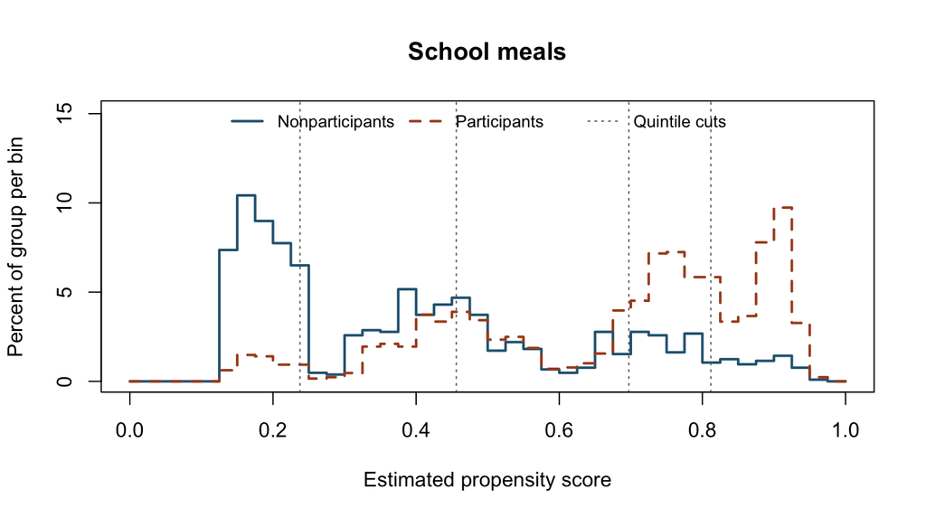

```r
plot_scores <- function(score, z, cuts, cut_label, title) {
  breaks <- seq(0, 1, by = 0.025)
  bin_pct <- function(s) 100 * hist(s, breaks, plot = FALSE)$counts / length(s)
  pct <- cbind(bin_pct(score[z == 0]), bin_pct(score[z == 1]))
  colors <- c("#286481", "#AB4D20", "grey40")
  matplot(breaks, rbind(pct, 0), type = "s", lty = 1:2, col = colors[1:2],
          lwd = 2, ylim = c(0, 1.45 * max(pct)), main = title,
          xlab = "Estimated propensity score", ylab = "Percent of group per bin")
  abline(v = cuts, col = colors[3], lty = 3)
  legend("top", c("Nonparticipants", "Participants", cut_label), col = colors,
         lty = 1:3, lwd = c(2, 2, 1), horiz = TRUE, bty = "n", cex = 0.82)
}
plot_scores(meal_score, z, score_cuts(meal_score, 5)[2:5], "Quintile cuts", "School meals")
```

The dotted lines mark the quintiles. The highest quintile includes 400 participants and 66 nonparticipants. Comparisons near the upper end rely on fewer nonparticipants, so we examine covariate balance as well as group counts.

### Step 2. Check whether stratification improves covariate balance

First use each baseline covariate as the variable being compared. For example, take the difference in food-stamp receipt **within each block**, then average the five differences using the fraction of children in each block. To put age, income indicators, and the other covariates on one graph, divide each difference by the same covariate-specific pooled SD before and after adjustment.

```r
NeymanSRE <- function(W, Y, strata.labels, by.stratum = FALSE) {
  n <- length(W)
  groups <- sort(unique(strata.labels))
  ests <- sapply(groups, function(gg) {
    in.stratum <- strata.labels == gg
    Y1 <- Y[in.stratum & W == 1]
    Y0 <- Y[in.stratum & W == 0]
    wt <- sum(in.stratum) / n
    est <- mean(Y1) - mean(Y0)
    est.var <- var(Y1) / length(Y1) + var(Y0) / length(Y0)
    c(wt = wt, est = est, est.var = est.var)
  })
  colnames(ests) <- groups
  if (by.stratum) return(t(ests))  # Show the terms used in the two sums below.
  neyman.est <- sum(ests["wt", ] * ests["est", ])
  neyman.var <- sum(ests["wt", ]^2 * ests["est.var", ])
  c(est = neyman.est, se = sqrt(neyman.var))
}
balance <- function(x, z, block) {
  t(sapply(as.data.frame(x), function(v) {
    pooled_sd <- sqrt((var(v[z == 1]) + var(v[z == 0])) / 2)
    before <- mean(v[z == 1]) - mean(v[z == 0])
    after <- NeymanSRE(z, v, block)[["est"]]
    c(before = before, after = after) / pooled_sd
  }))
}
```

```r
plot_balance <- function(b, title) {
  old <- par(mar = c(4.2, 7, 2.8, 1))
  on.exit(par(old))
  row <- rev(seq_len(nrow(b)))
  plot(range(c(0, b)), c(0.5, nrow(b) + 1.5), type = "n", yaxt = "n",
       xlab = "Standardized mean difference", ylab = "", main = title)
  axis(2, at = row, labels = rownames(b), las = 1, tick = FALSE)
  abline(v = 0, lty = 3)
  segments(b[, "before"], row, b[, "after"], row, col = "grey65")
  points(b[, "before"], row, pch = 1)
  points(b[, "after"], row, pch = 19, col = "#286481")
  legend("top", c("Before", "After stratification"), pch = c(1, 19),
         col = c("black", "#286481"), horiz = TRUE, bty = "n", cex = 0.85)
}
meal_balance <- balance(x, z, block)
knitr::kable(round(meal_balance, 2), col.names = c("Before blocking", "After blocking"))
```

|  | Before blocking | After blocking |
| --- | --- | --- |
| age | 0.06 | 0.00 |
| ChildSex | -0.03 | 0.00 |
| black | 0.25 | -0.01 |
| mexam | 0.35 | 0.00 |
| pir200_plus | -0.92 | -0.02 |
| WIC | 0.38 | 0.01 |
| Food_Stamp | 0.78 | 0.07 |
| fsdchbi | 0.43 | 0.00 |
| AnyIns | -0.14 | 0.00 |
| RefSex | -0.22 | -0.04 |
| RefAge | -0.17 | -0.02 |

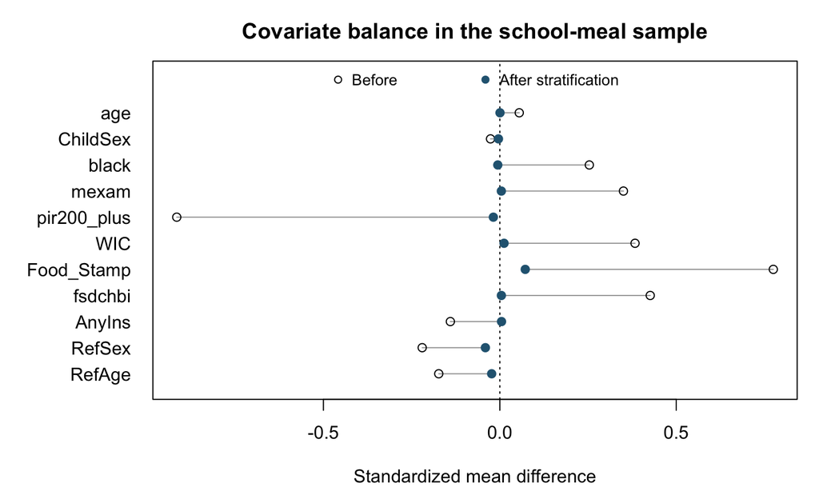

```r
plot_balance(meal_balance, "Covariate balance in the school-meal sample")
```

The table and plot compare all 2,330 children before and after blocking. For food-stamp receipt (`Food_Stamp`), the standardized difference falls from 0.78 to 0.07. A point near zero indicates similar means in the weighted comparison. Differences in individual blocks can still cancel.

### Step 3. Estimate the BMI difference by propensity-score stratification

**Start with the five strata from Step 1.** For each stratum, `NeymanSRE` computes its share of all 2,330 children (`wt`), the mean BMI of participants minus the mean BMI of nonparticipants (`est`), and the estimated variance of that difference (`est.var`).

```r
y <- meal$BMI
bmi_blocks <- NeymanSRE(z, y, block, by.stratum = TRUE)
knitr::kable(cbind(Stratum = seq_len(nrow(bmi_blocks)), bmi_blocks), digits = 3,
             row.names = FALSE, col.names = c("Stratum", "Weight", "BMI difference", "Variance of difference"))
```

| Stratum | Weight | BMI difference | Variance of difference |
| --- | --- | --- | --- |
| 1 | 0.201 | 0.115 | 0.386 |
| 2 | 0.199 | 0.569 | 0.261 |
| 3 | 0.200 | -0.420 | 0.325 |
| 4 | 0.200 | 0.090 | 0.381 |
| 5 | 0.200 | -0.933 | 0.654 |

In stratum 1, the mean BMIs are 19.124 and 19.009, giving a difference of 0.115. The block has 468 children, so its contribution is about $(468/2330) \times 0.115 = 0.023$ BMI units. Sum the five contributions. For the variance, multiply each stratum’s variance by its **squared** weight before adding.

```r
neyman.est <- sum(bmi_blocks[, "wt"] * bmi_blocks[, "est"])
neyman.var <- sum(bmi_blocks[, "wt"]^2 * bmi_blocks[, "est.var"])
print(round(c(estimate = neyman.est, SE = sqrt(neyman.var)), 3))
```

```
## estimate       SE
##   -0.116    0.283
```

The five-stratum BMI estimate is **−0.116** with SE **0.283** for the full school-meal sample.

**Repeat with different numbers of strata.** For each choice of `nn`, calculate the score quantiles, use `cut()` to assign the children to strata, then apply `NeymanSRE` to BMI. The same 2,330 children enter every column.

```r
n.strata <- c(5, 10, 20, 50, 80)
strat.res <- sapply(n.strata, function(nn) {
  q.pscore <- quantile(meal_score, (1:(nn - 1)) / nn)
  ps.strata <- cut(meal_score, breaks = c(0, q.pscore, 1), labels = 1:nn)
  NeymanSRE(z, y, ps.strata)
})
colnames(strat.res) <- n.strata
knitr::kable(round(strat.res, 3))
```

|  | 5 | 10 | 20 | 50 | 80 |
| --- | --- | --- | --- | --- | --- |
| est | -0.116 | -0.178 | -0.200 | -0.265 | -0.204 |
| se | 0.283 | 0.282 | 0.279 | 0.272 | NA |

**Check your understanding.** Why is the SE missing with 80 strata? Think about estimating a variance when a stratum has just one child in an arm.

## 2. Job training and 1978 earnings

The National Supported Work Demonstration offered temporary paid jobs and on-the-job support to people who had difficulty finding steady work. Did access to the program raise earnings in 1978? In Homework 2, you compared applicants randomly assigned to the program with applicants assigned to the control group. LaLonde asked whether researchers could recover the experimental result using a comparison group drawn from outside the experiment. [LaLonde (1986)](https://web.pdx.edu/~nwallace/PATF/Lalonde.pdf)

Here the 185 trainees (`treat = 1`) come from the experiment, and the 429 controls (`treat = 0`) come from the Panel Study of Income Dynamics (PSID), a separate household survey. This comparison is observational. For example, 71% of trainees had zero earnings in 1974, compared with 26% of survey controls. A difference in 1978 earnings could therefore reflect differences in work history as well as the effect of training. [MatchIt data description](https://kosukeimai.github.io/MatchIt/reference/lalonde.html)

Each row is one person. The columns `re74` and `re75` give earnings before training, and `re78` gives earnings after training, in dollars.

|  | treat | age | educ | race | married | nodegree | re74 | re75 | re78 |
| --- | --- | --- | --- | --- | --- | --- | --- | --- | --- |
| NSW1 | 1 | 37 | 11 | black | 1 | 1 | 0.00000 | 0.00000 | 9930.04600 |
| NSW2 | 1 | 22 | 9 | hispan | 0 | 1 | 0.00000 | 0.00000 | 3595.89400 |
| NSW3 | 1 | 30 | 12 | black | 0 | 0 | 0.00000 | 0.00000 | 24909.45000 |
| NSW4 | 1 | 27 | 11 | black | 0 | 1 | 0.00000 | 0.00000 | 7506.14600 |
| NSW5 | 1 | 33 | 8 | black | 0 | 1 | 0.00000 | 0.00000 | 289.78990 |
| NSW6 | 1 | 22 | 9 | black | 0 | 1 | 0.00000 | 0.00000 | 4056.49400 |
| NSW7 | 1 | 23 | 12 | black | 0 | 0 | 0.00000 | 0.00000 | 0.00000 |
| NSW8 | 1 | 32 | 11 | black | 0 | 1 | 0.00000 | 0.00000 | 8472.15800 |
| NSW9 | 1 | 22 | 16 | black | 0 | 0 | 0.00000 | 0.00000 | 2164.02200 |
| NSW10 | 1 | 33 | 12 | white | 1 | 0 | 0.00000 | 0.00000 | 12418.07000 |

[output cut: 604 more lines]

### Step 1. Estimate the propensity score

Fit one logistic regression for training participation using all seven pre-training covariates. Age, education, race, marital status, degree status, and earnings in 1974 and 1975 describe the groups before training. We reserve 1978 earnings (`re78`) for the outcome comparison.

```r
fit <- glm(treat ~ age + educ + race + married + nodegree + re74 + re75,
           data = lalonde, family = binomial())
lalonde$score <- fitted(fit)
```

### Step 2. Inspect overlap and trim

First form five score quintiles across all 614 people. The lowest quintile contains 122 controls and just one trainee. What would the treated mean in that quintile depend on?

```r
knitr::kable(with(lalonde, table(Treatment = treat, Quintile = score_blocks(score))))
```

|  | 1 | 2 | 3 | 4 | 5 |
| --- | --- | --- | --- | --- | --- |
| 0 | 122 | 116 | 101 | 53 | 37 |
| 1 | 1 | 7 | 21 | 71 | 85 |

Use two rules. First, keep scores from 0.10 to 0.90, inclusive. Second, keep scores in the **common range** (slide 24). Calculate that range in the full sample as the larger of the two group minima through the smaller of the two maxima.

```r
score_ranges <- with(lalonde, rbind(Controls = range(score[treat == 0]),
                                    Trainees = range(score[treat == 1])))
colnames(score_ranges) <- c("Minimum", "Maximum")
knitr::kable(score_ranges, digits = 5)
```

|  | Minimum | Maximum |
| --- | --- | --- |
| Controls | 0.00908 | 0.78917 |
| Trainees | 0.02495 | 0.85315 |

```r
e_L <- max(score_ranges[, "Minimum"])
e_U <- min(score_ranges[, "Maximum"])
fixed_range <- subset(lalonde, score >= 0.10 & score <= 0.90)
job <- subset(fixed_range, score >= e_L & score <= e_U)

job_counts <- rbind(`Before trimming` = table(lalonde$treat),
                    `After 0.10 to 0.90` = table(fixed_range$treat),
                    `After both rules` = table(job$treat))
colnames(job_counts) <- c("Controls", "Trainees")
knitr::kable(job_counts)
```

|  | Controls | Trainees |
| --- | --- | --- |
| Before trimming | 429 | 185 |
| After 0.10 to 0.90 | 166 | 175 |
| After both rules | 166 | 167 |

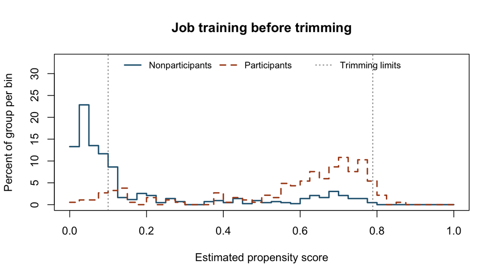

```r
plot_scores(lalonde$score, lalonde$treat, c(max(0.10, e_L), min(0.90, e_U)),
            "Trimming limits", "Job training before trimming")
```

The dotted lines mark the limits after applying both rules. The lower limit is **0.10** and the upper limit is **0.78917**, the largest observed control score. The blue histogram extends to 0.80 because its last occupied bin spans 0.775 to 0.80. The table uses individual scores to calculate the exact maximum.

The fixed cutoffs retain 166 controls and 175 trainees. The common-range rule removes eight more trainees, leaving **166 controls and 167 trainees**. The earnings analysis targets these 333 people.

### Step 3. Form strata in the retained sample

**Five score quintiles.** Recalculate the quintiles after trimming. Both groups are now represented in every stratum.

```r
job$quintile <- score_blocks(job$score)
knitr::kable(table(Group = job$treat, Quintile = job$quintile))
```

|  | 1 | 2 | 3 | 4 | 5 |
| --- | --- | --- | --- | --- | --- |
| 0 | 53 | 47 | 21 | 29 | 16 |
| 1 | 14 | 19 | 46 | 42 | 46 |

**How well do the five quintiles balance the covariates?** For each baseline variable, use `NeymanSRE` to calculate the weighted average of its within-quintile trainee-minus-control differences. Divide by its estimated standard error to get a balance $t$ statistic. Zero means the weighted difference is zero. The dashed lines at $\pm1.96$ are reference values.

```r
baseline <- model.matrix(~ age + educ + race + married + nodegree + re74 + re75, job)[, -1]
covariate_t <- function(strata) {
  apply(baseline, 2, function(v) {
    result <- NeymanSRE(job$treat, v, strata)
    unname(result["est"] / result["se"])
  })
}
t_quintile <- covariate_t(job$quintile)
```

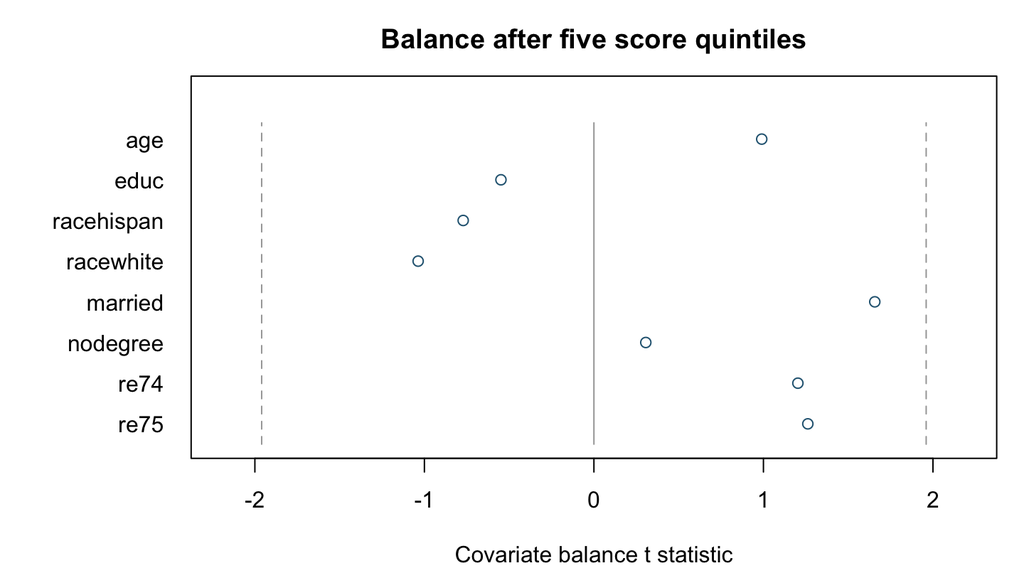

```r
plot_covariate_t(t_quintile)
```

All eight statistics fall inside the reference lines, but marital status ($t=1.66$), 1975 earnings ($t=1.26$), and 1974 earnings ($t=1.20$) still have noticeable differences. The quintile cutoffs give blocks of roughly equal size. Could different cutoffs bring those differences closer to zero?

**Sequential splitting.** Start again with all 333 retained people in one block. The overlap plot in Step 2 shows probabilities. For the splitting rule on slide 25, convert each retained probability $\hat e$ to its log-odds, $\ell = \log[\hat e/(1-\hat e)]$.

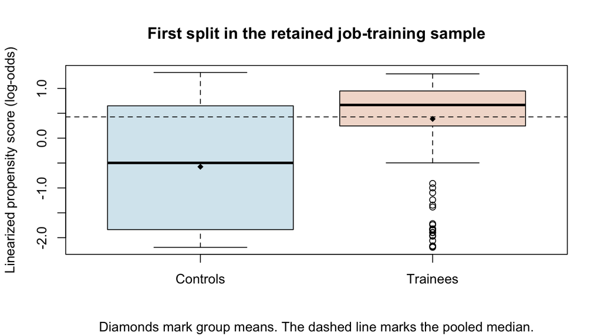

```r
job$logit_score <- qlogis(job$score)
score_t <- function(s, z) {
  unname(t.test(s[z == 1], s[z == 0], var.equal = TRUE)$statistic)
}
first_median <- median(job$logit_score)
first_t <- with(job, score_t(logit_score, treat))

boxplot(logit_score ~ treat, data = job, names = c("Controls", "Trainees"),
        col = c("#D7E8EF", "#F2DCD1"), xlab = "",
        ylab = "Linearized propensity score (log-odds)",
        main = "First split in the retained job-training sample",
        sub = "Diamonds mark group means. The dashed line marks the pooled median.")
abline(h = first_median, lty = 2)
points(1:2, with(job, tapply(logit_score, treat, mean)), pch = 18)
```

1. **Should we split?** Compare the two group means (diamonds) using the pooled two-sample $t$ statistic. They are 8.31 standard errors apart. This exceeds the threshold of **1.96**, so we try a split.
2. **Where do we split?** The dashed line marks the median log-odds across everyone in this block, **0.43**, equivalent to a propensity score of **0.605**. Put lower values in one block and higher values in the other. Randomly divide ties at the median.
3. **When do we stop?** Repeat the comparison within each new block. Try a split only if the block has at least 40 people and keep it only if each child has at least four controls and four trainees. Also stop when all scores are equal or $|t| \leq 1.96$.

```r
split_block <- function(id) {
  s <- job$logit_score[id]
  z <- job$treat[id]
  if (length(id) < 40 || diff(range(s)) == 0) return(list(id))
  if (abs(score_t(s, z)) <= 1.96) return(list(id))

  cutoff <- median(s)
  left <- s < cutoff
  ties <- which(s == cutoff)
  ties <- ties[sample.int(length(ties))]       # Randomly divide ties at the median
  left[head(ties, round(length(ties) / 2))] <- TRUE
  if (min(table(factor(left, levels = c(FALSE, TRUE)), z)) < 4) return(list(id))
  c(split_block(id[left]), split_block(id[!left]))
}

set.seed(0)
blocks <- split_block(seq_len(nrow(job)))
job$block <- integer(nrow(job))
for (b in seq_along(blocks)) job$block[blocks[[b]]] <- b
print(with(job, table(Treatment = treat, Block = block)))
```

```
##          Block
## Treatment   1   2   3   4
##         0  67  28  14  57
##         1  16  13  28 110
```

### Step 4. Check the final blocks and compare earnings

Recalculate each covariate’s balance $t$ statistic under the four sequential blocks. Both methods use the same 333 people. On each row of the plot, compare the open circle (five quintiles) with the filled dot (four sequential blocks). Which is closer to zero?

```r
t_sequential <- covariate_t(job$block)
comparison <- cbind(`Before blocking` = covariate_t(rep(1, nrow(job))),
                    `Five quintiles` = t_quintile, `Four sequential blocks` = t_sequential)
knitr::kable(round(comparison, 2))
```

|  | Before blocking | Five quintiles | Four sequential blocks |
| --- | --- | --- | --- |
| age | 0.54 | 0.99 | 0.50 |
| educ | -0.89 | -0.55 | -0.29 |
| racehispan | -4.37 | -0.77 | -0.36 |
| racewhite | -5.22 | -1.04 | -0.47 |
| married | 0.12 | 1.66 | 0.56 |
| nodegree | 1.10 | 0.31 | 0.54 |
| re74 | -0.29 | 1.20 | 0.71 |
| re75 | -0.35 | 1.26 | 0.59 |

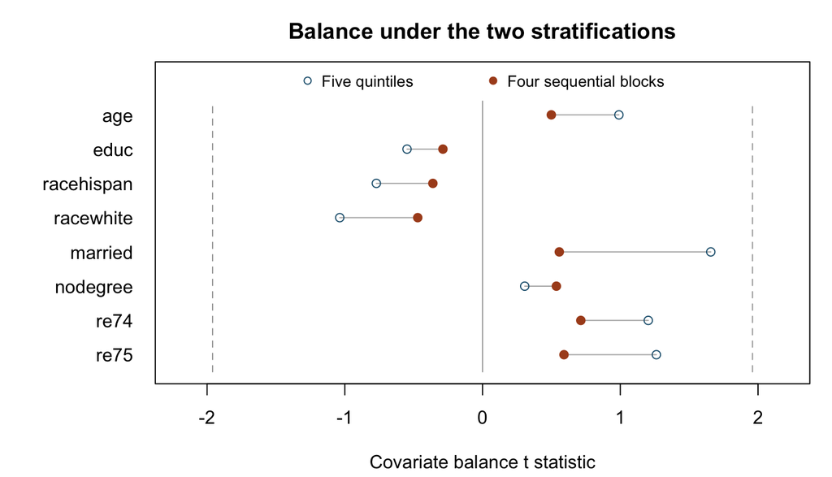

```r
plot_covariate_t(t_quintile, t_sequential)
```

**Seven of the eight covariate contrasts move closer to zero with four blocks.** Marital status drops from 1.66 to 0.56, and 1975 earnings drops from 1.26 to 0.59. The largest absolute $t$ across covariates falls from 1.66 to 0.71. Degree status is the exception (0.31 to 0.54). Here, choosing where to split improves overall balance even with one fewer block.

Use these four blocks to compare 1978 earnings.

```r
p <- with(job, NeymanSRE(treat, re78, block, by.stratum = TRUE))
earnings <- with(job, NeymanSRE(treat, re78, block))
ci <- earnings[["est"]] + c(-1, 1) * 1.96 * earnings[["se"]]
print(round(c(earnings, lower = ci[1], upper = ci[2])))
```

```
##   est    se lower upper
##   941   887  -797  2680
```

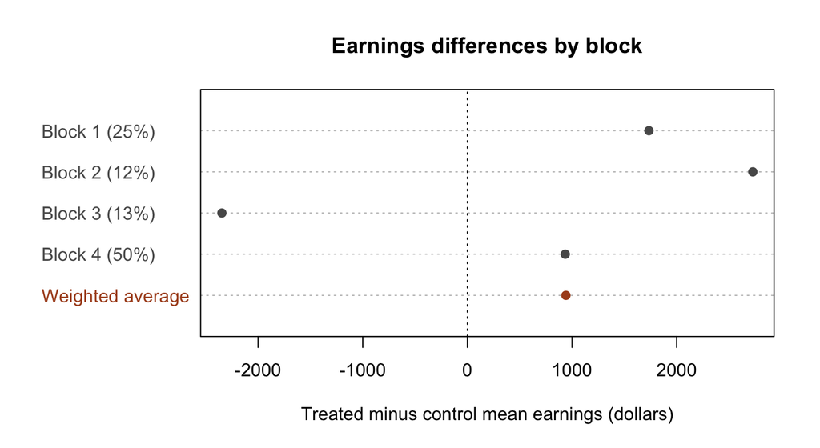

```r
block_labels <- sprintf("Block %d (%.0f%%)", seq_len(nrow(p)), 100 * p[, "wt"])
dotchart(rev(c(p[, "est"], earnings[["est"]])),
         labels = rev(c(block_labels, "Weighted average")), pch = 19,
         color = rev(c(rep("grey35", nrow(p)), "#AB4D20")),
         xlab = "Treated minus control mean earnings (dollars)", main = "Earnings differences by block")
abline(v = 0, lty = 3)
```

The lowest-score block contains 67 controls and 16 trainees. It contributes 83/333, or about 25%, of the weight. Across the four blocks, trainees earned an estimated **$941 more** in 1978 (SE **$887**, approximate 95% interval −$797 to $2,680). The interval includes zero and treats the chosen blocks as fixed. A causal interpretation requires overlap and that the measured covariates account for confounding.